# Experiments in language evolution: inferences from closed- vs open-ended semantic space paradigms

Data modeling

analysis by Aleksandra Ćwiek

24 November, 2025

# 1 What this document does

**Purpose.** This notebook fits and evaluates **baseline hierarchical models** for three outcome measures that capture how well participants’ free-text responses match target concepts:

1. `binary_guess` — whether the response was judged exact/near-exact (yes/no),
2. `judged_similarity` — coder-assigned similarity on a four-point scale,
3. `cosine_rescaled` — automatic cosine similarity (ConceptNet, rescaled to [0,1]).

Each outcome is analyzed separately. We summarize posterior distributions, report Bayesian R², and check convergence/diagnostics.

**Inputs.** One cleaned, analysis-ready dataset from `1_preparation.Rmd` (`data/final_df.csv`), containing participant IDs, stimulus/concept IDs, language, and the three outcome measures.

**Outputs.**

- Cached fitted models in `models/` (RDS files).
- Summary tables (posterior means/HDIs, random-effect SDs, Bayesian R²).
- Diagnostic plots and posterior predictive checks.
- Figures saved to `plots/2_modeling/` (auto-saved with stable numbering).

# 2 Data preparation

## 2.1 Source setup

```r
########## folders ##########
library(here)

setwd(dirname(rstudioapi::getActiveDocumentContext()$path))

parentfolder <- dirname(getwd())

data          <- paste0(parentfolder, '/data/')
models        <- paste0(parentfolder, '/models/')
plots         <- paste0(parentfolder, '/plots/')
scripts       <- paste0(parentfolder, '/scripts/')

########## source file ##########

#source(paste0(scripts, "adjectives-preparation.R"))

#################### packages ####################
# Core tidyverse for wrangling + plotting; janitor/skimr for quick structure checks; patchwork for combining plots
library(tidyverse)
library(janitor)
library(skimr)
library(knitr)
library(cowplot)
library(ggdist)
library(readxl)
library(lubridate)
library(patchwork)
library(hexbin)
library(PRROC)

# Bayesian
library(brms);
library(loo);packageVersion("loo")
```

```
## [1] '2.8.0'
```

```r
library(HDInterval);packageVersion("HDInterval")
```

```
## [1] '0.2.4'
```

```r
library(cmdstanr);
library(emmeans);packageVersion("emmeans")
```

```
## [1] '2.0.0'
```

```r
library(posterior);
library(bayesplot);
library(BayesFactor);
library(tidybayes);packageVersion("tidybayes")
```

```
## [1] '3.0.7'
```

```r
library(bayestestR);
library(cmdstanr)
options(brms.backend = "cmdstanr") # Speed gain: ~30-50% faster than rstan
options(brms.file_refit = "on_change")  # only refit if model changes

# use all available cores for parallel computing
options(mc.cores = parallel::detectCores())

# Keep plots/readability consistent
theme_set(theme_minimal(base_size = 12) + panel_border())

colorBlindBlack8  <- c("#000000", "#E69F00", "#56B4E9", "#009E73",
                       "#F0E442", "#0072B2", "#D55E00", "#CC79A7")
```

```r
# --- figure & table captions ---
outputFormat <- knitr::opts_knit$get("rmarkdown.pandoc.to"); if (is.null(outputFormat)) outputFormat <- ""
capTabNo <- 1L; capFigNo <- 1L
.last_fig_no <- NA_integer_

capTab <- function(x){
  if (outputFormat == 'html'){
    x <- paste0("**Table ", capTabNo, ".** ", x)
    capTabNo <<- capTabNo + 1L
  }
  x
}

capFig <- function(x, show_R_version=FALSE, show_package_versions=NULL, is_map=FALSE){
  if (outputFormat == 'html'){
    assign(".last_fig_no", capFigNo, envir = .GlobalEnv) # remember current number
    x <- paste0("**Figure ", capFigNo, ".** ", x)
    capFigNo <<- capFigNo + 1L
  }
  x
}

# --- plot hook to auto-save ---
.default_plot_hook <- knitr::knit_hooks$get("plot")
.has_magick <- requireNamespace("magick", quietly = TRUE)

knitr::knit_hooks$set(plot = function(x, options){
  res <- if (is.function(.default_plot_hook)) .default_plot_hook(x, options) else NULL

  if (!is.null(options$fig.cap)) {
    fig_no <- get(".last_fig_no", envir = .GlobalEnv, inherits = FALSE)
    if (!is.na(fig_no)) {
      fig_no_str <- sprintf("%02d", fig_no)

      # subfolder = Rmd filename without extension
      rmd_name <- tools::file_path_sans_ext(basename(knitr::current_input()))
      target_dir <- file.path(plots, rmd_name)
      if (!dir.exists(target_dir)) dir.create(target_dir, recursive = TRUE)

      png_out <- file.path(target_dir, paste0("Figure_", fig_no_str, ".png"))
      tif_out <- file.path(target_dir, paste0("Figure_", fig_no_str, ".tif"))

      file.copy(x, png_out, overwrite = TRUE)

      if (.has_magick) {
        img <- magick::image_read(png_out)
        magick::image_write(img, path = tif_out, format = "tiff", compression = "lzw")
      } else {
        file.copy(png_out, tif_out, overwrite = TRUE)
      }
    }
  }

  res
})
```

Other helpers

```r
bb_corr <- function(x, y, R = 4000, seed = 1708) {
  stopifnot(length(x) == length(y))
  set.seed(seed)
  n <- length(x)
  out <- numeric(R)
  for (r in seq_len(R)) {
    w <- rexp(n)          # Dirichlet via i.i.d. Exponential then normalize
    w <- w / sum(w)
    mx <- sum(w * x); my <- sum(w * y)
    sx <- sqrt(sum(w * (x - mx)^2))
    sy <- sqrt(sum(w * (y - my)^2))
    out[r] <- sum(w * (x - mx) * (y - my)) / (sx * sy)
  }
  out
}

summ_post <- function(draws, name){
  h <- hdi(draws, ci = 0.95)
  tibble(pair = name,
         mean = mean(draws),
         median = median(draws),
         hdi_low = h$CI_low,
         hdi_high = h$CI_high)
}

bf_bic <- function(y, x){
  fit1 <- lm(y ~ x)
  fit0 <- lm(y ~ 1)
  BIC0 <- BIC(fit0); BIC1 <- BIC(fit1)
  # BF10 ≈ exp((BIC0 - BIC1)/2)
  exp((BIC0 - BIC1)/2)
}
```

## 2.2 Load in data frames

```r
df    <- read_csv(paste0(data, "final_df.csv"))  %>% clean_names()
cats  <- read_csv(paste0(data, "meaning_categories.csv")) %>% clean_names()
```

# 3 Correlations

```r
dat_cor <- df %>%
  select(cosine = cosine_rescaled, judged = ord_norm, binary = bin_f) %>%
  drop_na()
```

Pearson correlations (with CIs)

```r
pearson_mat <- cor(dat_cor, use = "pairwise.complete.obs", method = "pearson")
pearson_mat
```

```
##           cosine    judged    binary
## cosine 1.0000000 0.8326525 0.6817019
## judged 0.8326525 1.0000000 0.7959914
## binary 0.6817019 0.7959914 1.0000000
```

Pairwise Pearson tests (p-values + CI)

```r
pearson_tests <- list(
  cosine_judged = cor.test(dat_cor$cosine, dat_cor$judged),
  cosine_binary = cor.test(dat_cor$cosine, dat_cor$binary),
  judged_binary = cor.test(dat_cor$judged, dat_cor$binary)
)
pearson_tests
```

```
## $cosine_judged
##
##  Pearson's product-moment correlation
##
## data:  dat_cor$cosine and dat_cor$judged
## t = 241.79, df = 25861, p-value < 2.2e-16
## alternative hypothesis: true correlation is not equal to 0
## 95 percent confidence interval:
##  0.8288764 0.8363527
## sample estimates:
##       cor
## 0.8326525
##
##
## $cosine_binary
##
##  Pearson's product-moment correlation
##
## data:  dat_cor$cosine and dat_cor$binary
## t = 149.84, df = 25861, p-value < 2.2e-16
## alternative hypothesis: true correlation is not equal to 0
## 95 percent confidence interval:
##  0.6751235 0.6881719
## sample estimates:
##       cor
## 0.6817019
##
##
## $judged_binary
##
##  Pearson's product-moment correlation
##
## data:  dat_cor$judged and dat_cor$binary
## t = 211.47, df = 25861, p-value < 2.2e-16
## alternative hypothesis: true correlation is not equal to 0
## 95 percent confidence interval:
##  0.7914823 0.8004140
## sample estimates:
##       cor
## 0.7959914
```

```r
pearson_tbl <- tibble(
  pair = c("cosine ~ judged", "cosine ~ binary", "judged ~ binary"),
  r = c(cor(dat_cor$cosine, dat_cor$judged),
        cor(dat_cor$cosine, dat_cor$binary),
        cor(dat_cor$judged, dat_cor$binary))
)

pearson_tbl
```

| pair | r |
| --- | --- |
| cosine ~ judged | 0.8326525 |
| cosine ~ binary | 0.6817019 |
| judged ~ binary | 0.7959914 |

```r
post_cos_jud <- bb_corr(dat_cor$cosine, dat_cor$judged, R = 8000, seed = 1708)
post_cos_bin <- bb_corr(dat_cor$cosine, dat_cor$binary, R = 8000, seed = 1708)
post_jud_bin <- bb_corr(dat_cor$judged, dat_cor$binary, R = 8000, seed = 1708)

bayes_corr_summary <- bind_rows(
  summ_post(post_cos_jud, "cosine ~ judged"),
  summ_post(post_cos_bin, "cosine ~ binary"),
  summ_post(post_jud_bin, "judged ~ binary")
)
bayes_corr_summary
```

| pair | mean | median | hdi_low | hdi_high |
| --- | --- | --- | --- | --- |
| cosine ~ judged | 0.8326147 | 0.8326454 | 0.8259853 | 0.8391864 |
| cosine ~ binary | 0.6816657 | 0.6816750 | 0.6701953 | 0.6928581 |
| judged ~ binary | 0.7959358 | 0.7959837 | 0.7863070 | 0.8057103 |

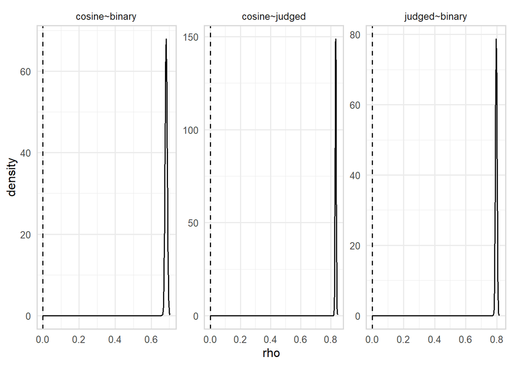

```r
# Posterior density plots
bind_rows(
  data.frame(rho = post_cos_jud, pair = "cosine~judged"),
  data.frame(rho = post_cos_bin, pair = "cosine~binary"),
  data.frame(rho = post_jud_bin, pair = "judged~binary")
) %>%
  ggplot(aes(rho)) + geom_density() + facet_wrap(~pair, scales = "free") +
  geom_vline(xintercept = 0, linetype = 2)
```

BIC-approx Bayes factors for “correlation != 0” For continuous-continuous: linear model; for (cont ~ binary): also linear is fine here.

```r
BF_cos_jud <- bf_bic(dat_cor$cosine, dat_cor$judged)
BF_cos_bin <- bf_bic(dat_cor$cosine, dat_cor$binary)
BF_jud_bin <- bf_bic(dat_cor$judged, dat_cor$binary)

bf_tbl <- tibble(
  pair = c("cosine ~ judged", "cosine ~ binary", "judged ~ binary"),
  BF10 = c(BF_cos_jud, BF_cos_bin, BF_jud_bin)
)
```

One clean summary table

```r
pearson_tbl %>%
  left_join(bayes_corr_summary, by = "pair") %>%
  left_join(bf_tbl, by = "pair")
```

| pair | r | mean | median | hdi_low | hdi_high | BF10 |
| --- | --- | --- | --- | --- | --- | --- |
| cosine ~ judged | 0.8326525 | 0.8326147 | 0.8326454 | 0.8259853 | 0.8391864 | Inf |
| cosine ~ binary | 0.6817019 | 0.6816657 | 0.6816750 | 0.6701953 | 0.6928581 | Inf |
| judged ~ binary | 0.7959914 | 0.7959358 | 0.7959837 | 0.7863070 | 0.8057103 | Inf |

# 4 Modeling

## 4.1 What we model

- **Binary accuracy**: `binary_guess ∈ {0,1}`, modeled with a **Bernoulli** distribution and logit link.
- **Ordinal judgments**: `judged_similarity ∈ {0,1,2,3}`, modeled with a **cumulative logit (ordinal)** likelihood.
- **Cosine similarity**: `cosine_rescaled ∈ [0,1]`, modeled with a **zero-one-inflated Beta (ZOIB)** or a simpler **Beta** after applying an ε-open transform to handle boundary values.

All models include varying intercepts for participants and stimuli to account for individual and item-level heterogeneity.

## 4.2 Full (for Cognitive Science)

```r
{
  set.seed(1708)

  ## ---- ensure models dir exists (you already have `models` as an absolute path) ----
  if (!dir.exists(models)) dir.create(models, recursive = TRUE, showWarnings = FALSE)

  ## ---- data prep (minimal; no z-scoring of cosine) ----
  ## ---------- COMPLETE-CASE DATA (based on cosine)
  # Rationale: use the same rows for all three outcomes to enable direct comparability
  if (!"ord_norm" %in% names(df)) df$ord_norm <- df$judged_similarity / 3
  df_brm <- subset(df, !is.na(cosine_rescaled))

  ## Keep exact-1 spike info for reporting (from original column but CC rows)
  ones_table_stim <- aggregate(I(df_brm$cosine_rescaled == 1) ~ stimulus_concept, data = df_brm, FUN = mean)
  names(ones_table_stim) <- c("stimulus_concept", "one_rate")

  df_brm$participant      <- factor(df_brm$participant)
  df_brm$stimulus_concept <- factor(df_brm$stimulus_concept)
  df_brm$native_language  <- factor(df_brm$native_language) # decided to do without it because it was not variable and caused much longer computation times
  df_brm$judged_ord       <- factor(df_brm$judged_similarity, levels = 0:3, ordered = TRUE)
 # Replace values extremely close to 1 with exactly 1
  df_brm$cosine_rescaled <- ifelse(
    !is.na(df_brm$cosine_rescaled) & df_brm$cosine_rescaled > 1 & df_brm$cosine_rescaled <
      1.001,
    1,
    df_brm$cosine_rescaled
  )

  ## ---- cosine preparation (rescaling to make comparable across measures) ----

  rescale_to_unit <- function(x) {
    eps <- 1e-10
    tiny <- 1e-12

    # Step 1: Epsilon-open to avoid exact boundaries
    x_open <- pmin(pmax(x - eps, tiny), 1 - tiny)

    # Step 2: Min-max rescale to [0,1]
    xmin <- min(x_open, na.rm = TRUE)
    xmax <- max(x_open, na.rm = TRUE)
    span <- xmax - xmin

    if (!is.finite(span) || span <= 0) {
      stop("Cannot rescale: no variation in x")
    }

    x_scaled <- (x_open - xmin) / span

    # Step 3: Ensure strictly in (0,1) for Beta
    x_final <- pmin(pmax(x_scaled, tiny), 1 - tiny)

    return(x_final)
  }

  # Apply to data
  # Nudge exact 1.0s only (keeping original scale)
  df_brm$cosine_original <- df_brm$cosine_rescaled
  df_brm$cosine_original[df_brm$cosine_original == 1.0] <- 0.999999

  # Full min-max rescaling (for comparable plot)
  df_brm$cosine_scaled <- rescale_to_unit(df_brm$cosine_rescaled)

  ## ---- very wide priors for baselines / couplings (not for ZOIB components) ----
  .pri_bin <- c(
    set_prior("normal(0, 5)", class = "Intercept"),
    #set_prior("normal(0, 2)", class = "b"),
    set_prior("student_t(3, 0, 5)", class = "sd")
  )
  .pri_ord <- c(
    set_prior("normal(0, 5)", class = "Intercept"),  # thresholds
    #set_prior("normal(0, 2)", class = "b"),
    set_prior("student_t(3, 0, 5)", class = "sd")
  )
  .pri_wide <- c(
    set_prior("normal(0, 5)", class = "Intercept"),
    #set_prior("normal(0, 2)", class = "b"),
    set_prior("student_t(3, 0, 5)", class = "sd")
  )

  ## ========================= BASELINES =========================
  .bin_rds <- file.path(models, "fit_bin.rds")
  if (file.exists(.bin_rds)) {
    fit_bin <- readRDS(.bin_rds)
  } else {
    fit_bin <- brm(
      binary_guess ~ 1 + (1|p|participant) + (1|s|stimulus_concept),
      data    = df_brm,
      family  = bernoulli(),
      prior   = .pri_bin,
      backend = "cmdstanr",
      chains  = 4, iter = 8000, warmup = 4000,
      threads = threading(2), cores = parallel::detectCores(),
      control = list(adapt_delta = 0.97, max_treedepth = 12),
      seed    = 1708, refresh = 100,
      save_pars = save_pars(all = TRUE)
    )
    saveRDS(fit_bin, .bin_rds)
  }

  .ord_rds <- file.path(models, "fit_ord.rds")
  if (file.exists(.ord_rds)) {
    fit_ord <- readRDS(.ord_rds)
  } else {
    fit_ord <- brm(
      judged_ord ~ 1 + (1|p|participant) + (1|s|stimulus_concept),
      data    = df_brm,
      family  = cumulative(link = "logit"),
      prior   = .pri_ord,
      backend = "cmdstanr",
      chains  = 4, iter = 10000, warmup = 4000,
      threads = threading(2), cores = parallel::detectCores(),
      control = list(adapt_delta = 0.99, max_treedepth = 13),
      seed    = 1708, refresh = 100,
      save_pars = save_pars(all = TRUE)
    )
    saveRDS(fit_ord, .ord_rds)
  }

  .cos_org_rds <- file.path(models, "fit_cos_org.rds")
  if (file.exists(.cos_org_rds)) {
    fit_cos_org <- readRDS(.cos_org_rds)
  } else {
    fit_cos_org <- brm(
      cosine_original ~ 1 + (1|p|participant) + (1|s|stimulus_concept),
      data    = df_brm,
      family  = Beta(),
      prior = c(
        set_prior("normal(0, 2)", class = "Intercept"),
        set_prior("student_t(3, 0, 2.5)", class = "sd"),
        set_prior("gamma(0.01, 0.01)", class = "phi")),
      backend = "cmdstanr",
      chains  = 4, iter = 10000, warmup = 4000,
      threads = threading(2), cores = parallel::detectCores(),
      control = list(adapt_delta = 0.99, max_treedepth = 13),
      seed    = 1708, refresh = 100,
      save_pars = save_pars(all = TRUE)
    )
    saveRDS(fit_cos_org, .cos_org_rds)
  }

  .cos_com_rds <- file.path(models, "fit_cos_com.rds")
  if (file.exists(.cos_com_rds)) {
    fit_cos_com <- readRDS(.cos_com_rds)
  } else {
    fit_cos_com <- brm(
      cosine_scaled ~ 1 + (1|p|participant) + (1|s|stimulus_concept),
      data    = df_brm,
      family  = Beta(),
      prior = c(
        set_prior("normal(0, 2)", class = "Intercept"),
        set_prior("student_t(3, 0, 2.5)", class = "sd"),
        set_prior("gamma(0.01, 0.01)", class = "phi")),
      backend = "cmdstanr",
      chains  = 4, iter = 10000, warmup = 4000,
      threads = threading(2), cores = parallel::detectCores(),
      control = list(adapt_delta = 0.99, max_treedepth = 13),
      seed    = 1708, refresh = 100,
      save_pars = save_pars(all = TRUE)
    )
    saveRDS(fit_cos_com, .cos_com_rds)
  }

  ## ---- compact Bayes R^2 (kept as r2_table) ----
  # Path to saved R2 summary
  .r2_rds <- file.path(models, "r2_table.rds")

  if (file.exists(.r2_rds)) {
    # If the summary table already exists, just load it
    r2_table <- readRDS(.r2_rds)
    message("Loaded existing r2_table from ", .r2_rds)

  } else {
    # Otherwise, compute it fresh from model fits
    .r2 <- function(fit) {
      r <- bayes_R2(fit)
      c(Estimate = mean(r),
        Q2.5 = quantile(r, .025),
        Q97.5 = quantile(r, .975))
    }

    r2_table <- data.frame(
      model = c("Binary (Bernoulli)", "Judged (Ordinal)", "Cosine (Beta)"),
      rbind(.r2(fit_bin), .r2(fit_ord), .r2(fit_cos_org))
    )

    # clean rounding
    r2_table$Estimate <- round(r2_table$Estimate, 3)
    r2_table$Q2.5     <- round(r2_table$Q2.5, 3)
    r2_table$Q97.5    <- round(r2_table$Q97.5, 3)

    # Save table to reuse later
    saveRDS(r2_table, .r2_rds)
    message("Saved new r2_table to ", .r2_rds)
  }


  ## ---- cleanup helpers (keep only model objects + r2_table + path vars) ----
  rm(list = c(".pri_bin",".pri_ord",".pri_wide",
              ".bin_rds",".ord_rds",".cos_org_rds", ".cos_com_rds",
              ".m_ord_cos_rds",".m_bin_cos_rds",".m_bin_jud_rds",".m_cos_jud_rds", ".r2_rds"))
}
```

## 4.3 Extract results

### 4.3.1 Convergence

Rhat and Bulk ESS:

```r
# ===== CONVERGENCE DIAGNOSTICS =====
# Extract Rhat and ESS for checking model quality

binary_diagnostics <- tibble(
  model = "binary",
  max_rhat = max(brms::rhat(fit_bin)),
  min_ess_bulk = min(brms::neff_ratio(fit_bin))
)
ordinal_diagnostics <- tibble(
  model = "ordinal",
  max_rhat = max(brms::rhat(fit_ord)),
  min_ess_bulk = min(brms::neff_ratio(fit_ord))
)

cosine_diagnostics <- tibble(
  model = "cosine",
  max_rhat = max(brms::rhat(fit_cos_com)),
  min_ess_bulk = min(brms::neff_ratio(fit_cos_com))
)

bind_rows(binary_diagnostics, ordinal_diagnostics, cosine_diagnostics)
```

| model | max_rhat | min_ess_bulk |
| --- | --- | --- |
| binary | 1.002919 | 0.16763204 |
| ordinal | NA | NA |
| cosine | 1.004350 | 0.04293504 |

Posterior predictive checks:

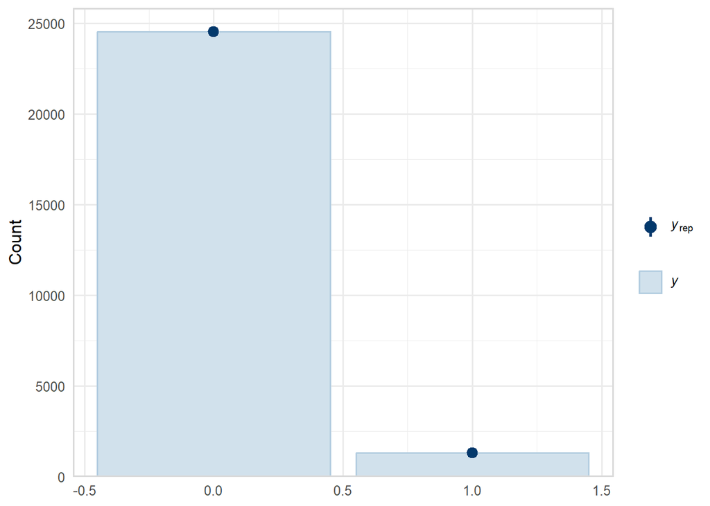

```r
pp_check(fit_bin, type = "bars", ndraws = 500)
```

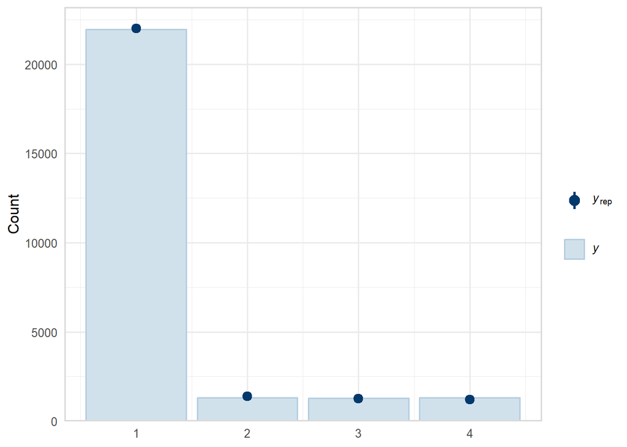

```r
pp_check(fit_ord, type = "bars", ndraws = 500)
```

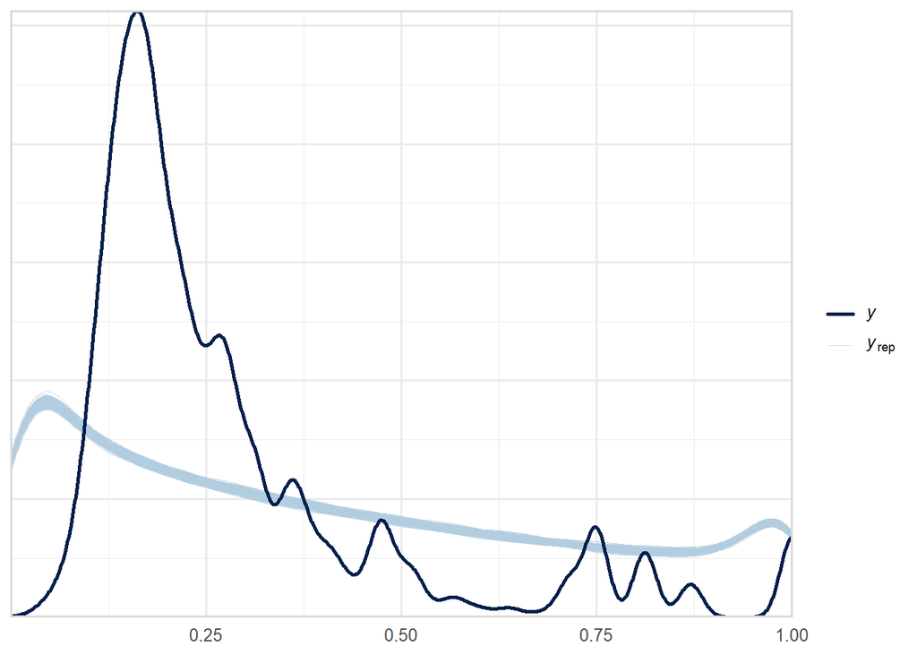

```r
pp_check(fit_cos_com, type = "dens_overlay", ndraws = 500)
```

R^2 for the models:

```r
r2_table
```

| model | Estimate | Q2.5.2.5. | Q97.5.97.5. | Q2.5 | Q97.5 |
| --- | --- | --- | --- | --- | --- |
| Binary (Bernoulli) | 0.322 | 0.03950441 | 0.4437303 | 0.040 | 0.444 |
| Judged (Ordinal) | 0.407 | 0.04449349 | 0.5502089 | 0.044 | 0.550 |
| Cosine (Beta) | 0.468 | 0.04794588 | 0.6262520 | 0.048 | 0.626 |

#### 4.3.1.1 Cosine scale verification

```r
# Extract stimulus posteriors from both models
stim_original <- fitted(fit_cos_org,
                       newdata = data.frame(stimulus_concept = levels(df_brm$stimulus_concept)),
                       re_formula = ~(1|stimulus_concept))

stim_scaled <- fitted(fit_cos_com,
                     newdata = data.frame(stimulus_concept = levels(df_brm$stimulus_concept)),
                     re_formula = ~(1|stimulus_concept))

# Perfect rank preservation
cor(stim_original[,"Estimate"], stim_scaled[,"Estimate"], method = "spearman")
```

```
## [1] 0.9884316
```

```r
# Should be as close to 1.0 as possible
```

Verify Rank Concordance

```r
# Extract stimulus-level predictions from both
get_stim_preds <- function(fit, label) {
  nd <- data.frame(stimulus_concept = levels(df_brm$stimulus_concept))
  preds <- fitted(fit, newdata = nd,
                  re_formula = ~(1|stimulus_concept),
                  summary = TRUE)
  tibble(
    stimulus = nd$stimulus_concept,
    mean = preds[, "Estimate"],
    model = label
  )
}

stim_both <- bind_rows(
  get_stim_preds(fit_cos_org, "Original scale"),
  get_stim_preds(fit_cos_com, "Rescaled")
)

# Rank correlation (should be perfect)
stim_wide <- stim_both %>%
  pivot_wider(names_from = model, values_from = mean)

cor(stim_wide$`Original scale`, stim_wide$`Rescaled`, method = "spearman")
```

```
## [1] 0.9884316
```

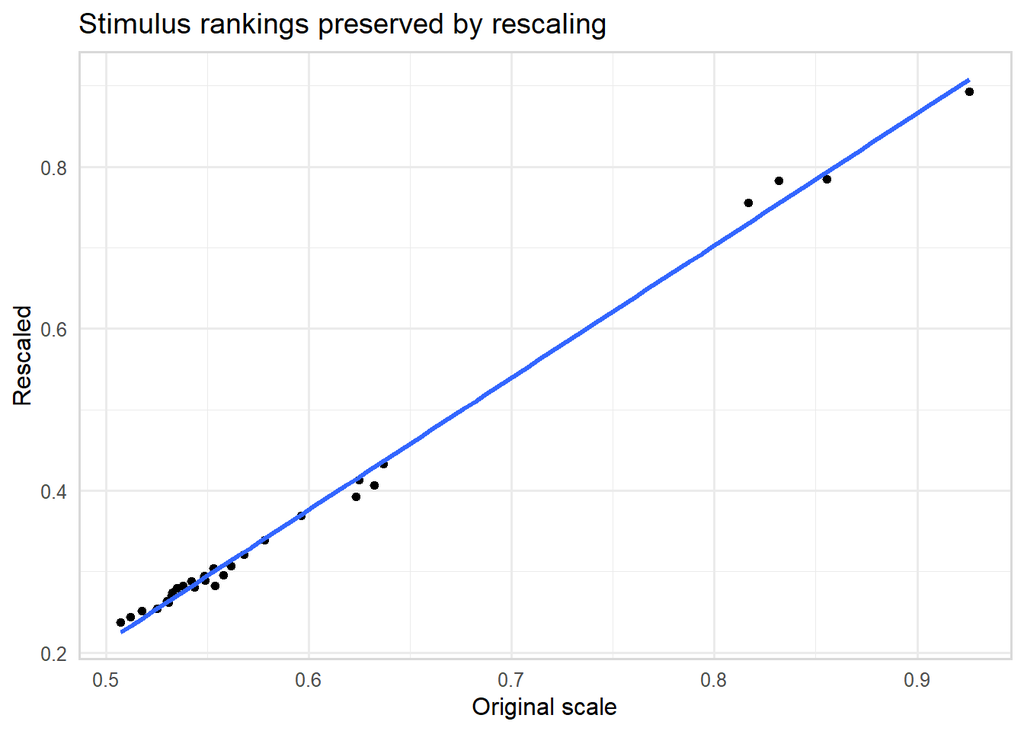

```r
# Should be 1.0 - perfect rank preservation

# Visualize
ggplot(stim_wide, aes(x = `Original scale`, y = `Rescaled`)) +
  geom_point() +
  geom_smooth(method = "lm", se = FALSE) +
  labs(title = "Stimulus rankings preserved by rescaling")
```

### 4.3.2 Model summaries

```r
# Binary model summary
summary(fit_bin)
```

```
##  Family: bernoulli
##   Links: mu = logit
## Formula: binary_guess ~ 1 + (1 | p | participant) + (1 | s | stimulus_concept)
##    Data: df_brm (Number of observations: 25863)
##   Draws: 4 chains, each with iter = 8000; warmup = 4000; thin = 1;
##          total post-warmup draws = 16000
##
## Multilevel Hyperparameters:
## ~participant (Number of levels: 200)
##               Estimate Est.Error l-95% CI u-95% CI Rhat Bulk_ESS Tail_ESS
## sd(Intercept)     1.50      0.11     1.29     1.73 1.00     4083     7530
##
## ~stimulus_concept (Number of levels: 30)
##               Estimate Est.Error l-95% CI u-95% CI Rhat Bulk_ESS Tail_ESS
## sd(Intercept)     3.48      0.67     2.43     5.02 1.00     4424     7598
##
## Regression Coefficients:
##           Estimate Est.Error l-95% CI u-95% CI Rhat Bulk_ESS Tail_ESS
## Intercept    -7.11      0.73    -8.65    -5.75 1.00     3127     5494
##
## Draws were sampled using sample(hmc). For each parameter, Bulk_ESS
## and Tail_ESS are effective sample size measures, and Rhat is the potential
## scale reduction factor on split chains (at convergence, Rhat = 1).
```

```r
binary_results <- tibble(
  parameter = c("Intercept", "SD_participant", "SD_stimulus"),
  mean = c(
    fixef(fit_bin)[1, "Estimate"],
    VarCorr(fit_bin)$participant$sd[1, "Estimate"],
    VarCorr(fit_bin)$stimulus_concept$sd[1, "Estimate"]
  ),
  ci_lower = c(
    fixef(fit_bin)[1, "Q2.5"],
    VarCorr(fit_bin)$participant$sd[1, "Q2.5"],
    VarCorr(fit_bin)$stimulus_concept$sd[1, "Q2.5"]
  ),
  ci_upper = c(
    fixef(fit_bin)[1, "Q97.5"],
    VarCorr(fit_bin)$participant$sd[1, "Q97.5"],
    VarCorr(fit_bin)$stimulus_concept$sd[1, "Q97.5"]
  )
)

binary_results
```

| parameter | mean | ci_lower | ci_upper |
| --- | --- | --- | --- |
| Intercept | -7.110667 | -8.654218 | -5.747273 |
| SD_participant | 1.496361 | 1.288349 | 1.730451 |
| SD_stimulus | 3.483871 | 2.431736 | 5.020696 |

The Bayesian logistic regression model for binary accuracy (exact/near-exact matches) revealed that guessing success was very low overall. The population-level intercept of β = -7.11 (95% HDI [-8.65, -5.75]) on the logit scale corresponds to a baseline probability of approximately 0.08% (less than 1 in 1000) of producing an exact match when not accounting for specific stimuli or participants. This extremely negative intercept confirms that exact semantic matches were rare events. The model revealed substantial heterogeneity at both levels: participant-level variation (SD = 1.50, 95% HDI [1.29, 1.73]) indicated that some individuals were consistently better at guessing across all stimuli, while stimulus-level variation (SD = 3.48, 95% HDI [2.43, 5.02]) was even larger, demonstrating that certain concepts were dramatically more guessable than others. The large stimulus SD relative to the participant SD suggests that item characteristics (e.g., iconicity, semantic domain) played a more important role than individual differences in determining success.

```r
# Ordinal model summary
summary(fit_ord)
```

```
##  Family: cumulative
##   Links: mu = logit
## Formula: judged_ord ~ 1 + (1 | p | participant) + (1 | s | stimulus_concept)
##    Data: df_brm (Number of observations: 25863)
##   Draws: 4 chains, each with iter = 10000; warmup = 4000; thin = 1;
##          total post-warmup draws = 24000
##
## Multilevel Hyperparameters:
## ~participant (Number of levels: 200)
##               Estimate Est.Error l-95% CI u-95% CI Rhat Bulk_ESS Tail_ESS
## sd(Intercept)     0.67      0.05     0.58     0.76 1.00     6211    11397
##
## ~stimulus_concept (Number of levels: 30)
##               Estimate Est.Error l-95% CI u-95% CI Rhat Bulk_ESS Tail_ESS
## sd(Intercept)     3.08      0.51     2.28     4.23 1.00     4096     8177
##
## Regression Coefficients:
##              Estimate Est.Error l-95% CI u-95% CI Rhat Bulk_ESS Tail_ESS
## Intercept[1]     3.90      0.56     2.80     5.03 1.00     1795     3904
## Intercept[2]     4.88      0.56     3.78     6.01 1.00     1799     3860
## Intercept[3]     6.19      0.56     5.09     7.32 1.00     1805     4012
##
## Further Distributional Parameters:
##      Estimate Est.Error l-95% CI u-95% CI Rhat Bulk_ESS Tail_ESS
## disc     1.00      0.00     1.00     1.00   NA       NA       NA
##
## Draws were sampled using sample(hmc). For each parameter, Bulk_ESS
## and Tail_ESS are effective sample size measures, and Rhat is the potential
## scale reduction factor on split chains (at convergence, Rhat = 1).
```

```r
ordinal_results <- tibble(
  parameter = c(paste0("Threshold_", 0:2), "SD_participant", "SD_stimulus"),
  mean = c(
    fixef(fit_ord)[, "Estimate"],
    VarCorr(fit_ord)$participant$sd[1, "Estimate"],
    VarCorr(fit_ord)$stimulus_concept$sd[1, "Estimate"]
  ),
  ci_lower = c(
    fixef(fit_ord)[, "Q2.5"],
    VarCorr(fit_ord)$participant$sd[1, "Q2.5"],
    VarCorr(fit_ord)$stimulus_concept$sd[1, "Q2.5"]
  ),
  ci_upper = c(
    fixef(fit_ord)[, "Q97.5"],
    VarCorr(fit_ord)$participant$sd[1, "Q97.5"],
    VarCorr(fit_ord)$stimulus_concept$sd[1, "Q97.5"]
  )
)

ordinal_results
```

| parameter | mean | ci_lower | ci_upper |
| --- | --- | --- | --- |
| Threshold_0 | 3.9028410 | 2.8028387 | 5.0339785 |
| Threshold_1 | 4.8795729 | 3.7825308 | 6.0082887 |
| Threshold_2 | 6.1915939 | 5.0930158 | 7.3248540 |
| SD_participant | 0.6654547 | 0.5800076 | 0.7622421 |
| SD_stimulus | 3.0835229 | 2.2825787 | 4.2341507 |

The cumulative logit model for ordinal judgments (0 = completely different, 1 = distantly related, 2 = similar, 3 = identical/near-identical) estimated three threshold parameters that define boundaries between adjacent response categories. The first threshold (between 0 and 1) was β = 3.90 (95% HDI [2.80, 5.03]), indicating a high barrier for responses to be considered even distantly related to targets. The second threshold (between 1 and 2) was β = 4.88 (95% HDI [3.78, 6.01]), and the third threshold (between 2 and 3) was β = 6.19 (95% HDI [5.09, 7.32]). These monotonically increasing thresholds show that each step up in similarity rating required increasingly strong evidence, with the gap between categories 2 and 3 (similar vs. identical) being particularly large. Participant-level variation was moderate (SD = 0.665, 95% HDI [0.580, 0.762]), suggesting relatively consistent rating behavior across individuals. However, stimulus-level variation was substantial (SD = 3.08, 95% HDI [2.28, 4.23]), confirming that some stimuli consistently elicited higher similarity ratings than others. The pattern mirrors the binary model: item characteristics mattered more than individual differences in determining semantic overlap between responses and targets.

```r
# Cosine model summary
summary(fit_cos_com)
```

```
##  Family: beta
##   Links: mu = logit
## Formula: cosine_scaled ~ 1 + (1 | p | participant) + (1 | s | stimulus_concept)
##    Data: df_brm (Number of observations: 25863)
##   Draws: 4 chains, each with iter = 10000; warmup = 4000; thin = 1;
##          total post-warmup draws = 24000
##
## Multilevel Hyperparameters:
## ~participant (Number of levels: 200)
##               Estimate Est.Error l-95% CI u-95% CI Rhat Bulk_ESS Tail_ESS
## sd(Intercept)     0.35      0.02     0.31     0.39 1.00     2281     5561
##
## ~stimulus_concept (Number of levels: 30)
##               Estimate Est.Error l-95% CI u-95% CI Rhat Bulk_ESS Tail_ESS
## sd(Intercept)     0.88      0.12     0.68     1.16 1.00     3148     6647
##
## Regression Coefficients:
##           Estimate Est.Error l-95% CI u-95% CI Rhat Bulk_ESS Tail_ESS
## Intercept    -0.53      0.16    -0.86    -0.22 1.00     1030     2100
##
## Further Distributional Parameters:
##     Estimate Est.Error l-95% CI u-95% CI Rhat Bulk_ESS Tail_ESS
## phi     2.75      0.02     2.71     2.79 1.00    32848    18136
##
## Draws were sampled using sample(hmc). For each parameter, Bulk_ESS
## and Tail_ESS are effective sample size measures, and Rhat is the potential
## scale reduction factor on split chains (at convergence, Rhat = 1).
```

```r
cosine_results <- tibble(
  parameter = c("Intercept_mu", "Phi", "SD_participant", "SD_stimulus"),
  mean = c(
    fixef(fit_cos_com)[1, "Estimate"],
    summary(fit_cos_com)$spec_pars[1, "Estimate"], # phi parameter
    VarCorr(fit_cos_com)$participant$sd[1, "Estimate"],
    VarCorr(fit_cos_com)$stimulus_concept$sd[1, "Estimate"]
  ),
  ci_lower = c(
    fixef(fit_cos_com)[1, "Q2.5"],
    NA,
    VarCorr(fit_cos_com)$participant$sd[1, "Q2.5"],
    VarCorr(fit_cos_com)$stimulus_concept$sd[1, "Q2.5"]
  ),
  ci_upper = c(
    fixef(fit_cos_com)[1, "Q97.5"],
    NA,
    VarCorr(fit_cos_com)$participant$sd[1, "Q97.5"],
    VarCorr(fit_cos_com)$stimulus_concept$sd[1, "Q97.5"]
  )
)

cosine_results
```

| parameter | mean | ci_lower | ci_upper |
| --- | --- | --- | --- |
| Intercept_mu | -0.5337073 | -0.8626622 | -0.2169218 |
| Phi | 2.7501264 | NA | NA |
| SD_participant | 0.3459420 | 0.3113159 | 0.3859001 |
| SD_stimulus | 0.8784398 | 0.6760907 | 1.1581707 |

The Beta regression model for cosine similarity scores (computational semantic overlap based on ConceptNet embeddings, scaled 0-1) estimated a population-level intercept of β = -0.534 (95% HDI [-0.863, -0.217]) on the logit scale. When back-transformed to the probability scale, this corresponds to a mean cosine similarity of approximately 0.37, indicating that participant responses were, on average, semantically closer to unrelated concepts than to the target meanings. The precision parameter φ = 2.75 describes the concentration of the Beta distribution, with higher values indicating less variance around the mean; this moderate value suggests considerable spread in cosine scores. Between-participant variation was relatively small (SD = 0.346, 95% HDI [0.311, 0.386]), indicating that participants showed similar levels of semantic distance from targets on average. In contrast, between-stimulus variation was substantially larger (SD = 0.878, 95% HDI [0.676, 1.16]), confirming that the semantic guessability of stimuli varied dramatically. As with the other two measures, this pattern demonstrates that the success or failure of semantic guessing was primarily driven by properties of the stimuli (e.g., which semantic domain they belonged to, their acoustic iconicity) rather than by individual participant abilities.

### 4.3.3 Compare outcome scales (pasted from claude just like that)

Binary model: P(Y = 1) → [0, 1] probability Cosine model: E(Y) → [0, 1] continuous Ordinal model: P(Y = 0,1,2,3) → How to map to [0,1]?

Ordinal to continuous mapping

```r
# Helper function: extract expected value from ordinal model
get_ordinal_expected <- function(fit_ord, newdata) {
  # Get predicted probabilities for each category
  # fitted() for ordinal gives P(Y = k) for each k
  pred <- fitted(fit_ord, newdata = newdata,
                 re_formula = ~(1|stimulus_concept),
                 summary = FALSE)  # Get all posterior draws

  # pred is array: draws × observations × categories
  # Dimensions: [n_draws, n_stimuli, 4 categories]

  # Compute expected value for each draw and stimulus
  # E(Y) = 0*P(Y=0) + 1*P(Y=1) + 2*P(Y=2) + 3*P(Y=3)
  expected_vals <- apply(pred, c(1, 2), function(probs) {
    sum(c(0, 1, 2, 3) * probs)
  })


  # Normalize to [0, 1]
  expected_vals_norm <- expected_vals / 3

  # Return summary statistics
  tibble(
    stimulus = newdata$stimulus_concept,
    Estimate = apply(expected_vals_norm, 2, mean),
    Q2.5 = apply(expected_vals_norm, 2, quantile, 0.025),
    Q97.5 = apply(expected_vals_norm, 2, quantile, 0.975)
    )
  }

  # Create newdata for all stimuli
  nd_stim <- data.frame(stimulus_concept = levels(df_brm$stimulus_concept))

  # Extract predictions from all three models
  stim_binary <- fitted(fit_bin, newdata = nd_stim,
                        re_formula = ~(1|stimulus_concept),
                        summary = TRUE) %>%
    as_tibble() %>%
    mutate(stimulus = nd_stim$stimulus_concept,
           measure = "Binary")

  stim_ordinal <- get_ordinal_expected(fit_ord, nd_stim) %>%
    mutate(measure = "Judged")

  stim_cosine <- fitted(fit_cos_com, newdata = nd_stim,
                        re_formula = ~(1|stimulus_concept),
                        summary = TRUE) %>%
    as_tibble() %>%
    mutate(stimulus = nd_stim$stimulus_concept,
           measure = "Cosine (rescaled)")

  # Combine all three
  all_measures <- bind_rows(
    stim_binary %>% select(stimulus, Estimate, Q2.5, Q97.5, measure),
    stim_ordinal %>% select(stimulus, Estimate, Q2.5, Q97.5, measure),
    stim_cosine %>% select(stimulus, Estimate, Q2.5, Q97.5, measure)
  ) %>%
    left_join(cats, by = c("stimulus" = "meaning"))
```

Across all three evaluation measures—binary accuracy, ordinal similarity judgments, and computational cosine similarity—a consistent pattern emerged: stimulus-level variation substantially exceeded participant-level variation. This indicates that the guessability of novel vocalizations and ape gestures was primarily determined by properties of the signals themselves (their iconicity, semantic domain, or other stimulus characteristics) rather than by individual cognitive differences among participants. The extremely low intercepts for binary accuracy and the below-midpoint intercept for cosine similarity both confirm that, in absolute terms, semantic guessing success was limited when the response space was unrestricted, even though relative differences between stimuli were substantial and systematic.

### 4.3.4 Visualizing data

Visualization 1: Heatmap

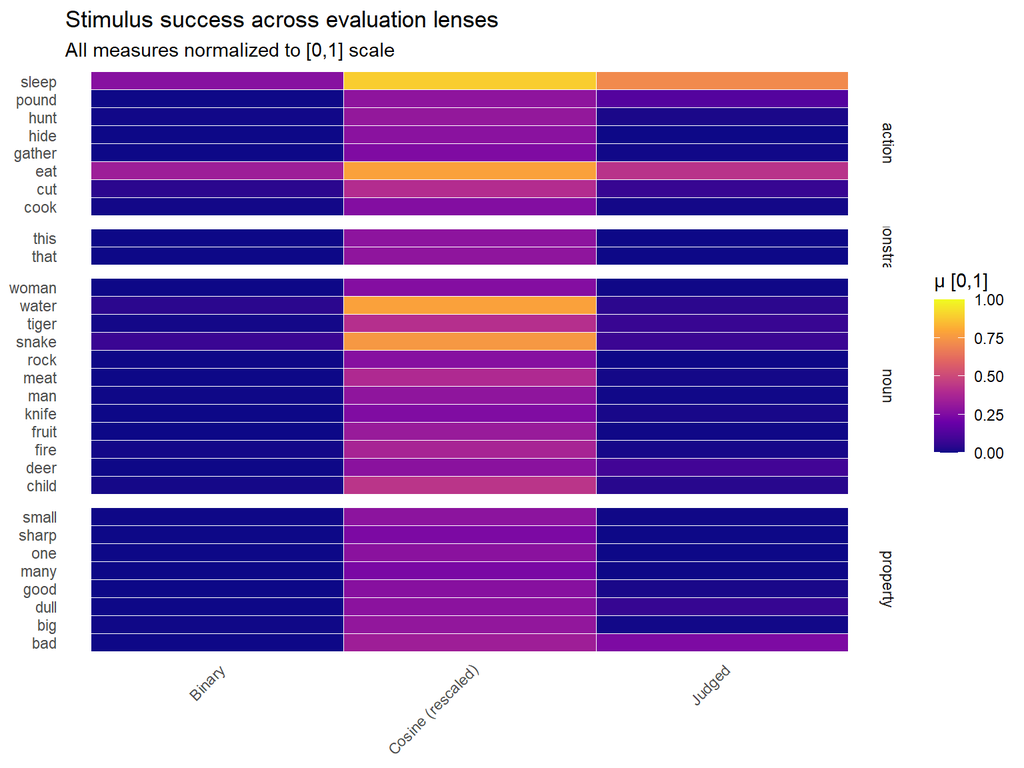

**Figure 1.** Heatmap plot.

Visualization 2: Lollipop Plot

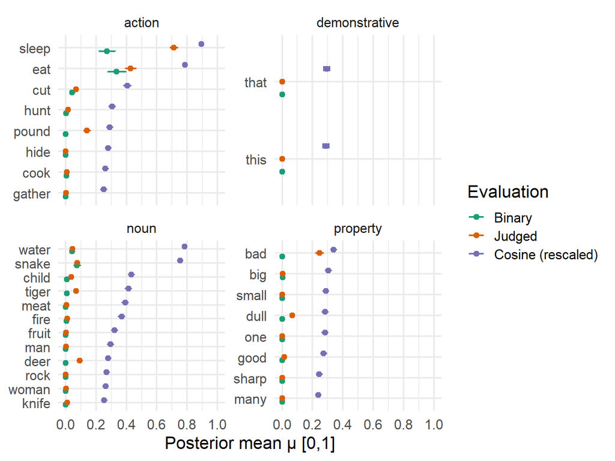

**Figure 2.** Lolipop plot.

Visualization 3: “Progressive Inclusivity” Plot This directly shows your research question:

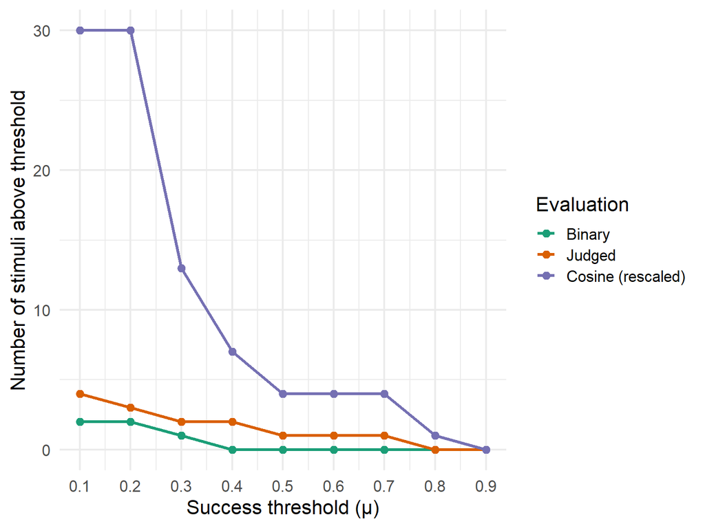

**Figure 3.** Progressive inclusivity plot.

Visualization 4: Direct Comparison Grid

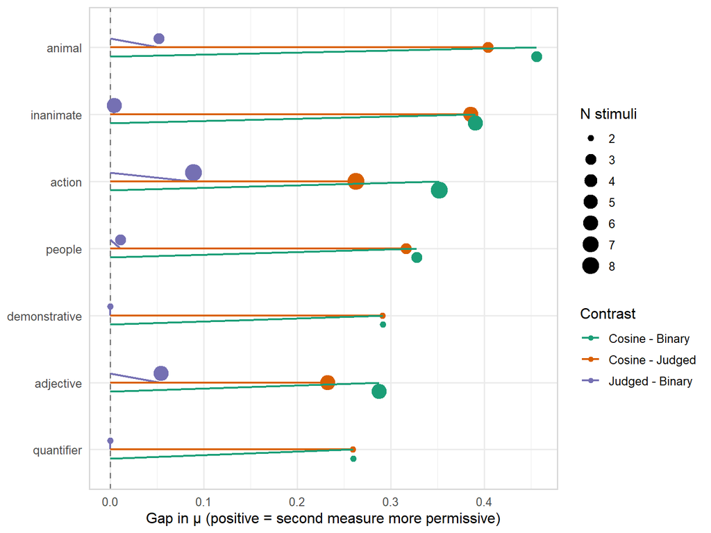

**Figure 4.** Direct comparison grid.

Critical Code Block: Getting Ordinal Expected Values If the above get_ordinal_expected() function doesn’t work with your brms version, here’s a more robust alternative:

```r
# Alternative method using posterior_predict
get_ordinal_expected_v2 <- function(fit_ord, newdata) {
  # Get posterior predicted categories for each draw
  pred_cats <- posterior_predict(fit_ord,
                                 newdata = newdata,
                                 re_formula = ~(1|stimulus_concept))

  # pred_cats is matrix: draws × observations
  # Values are 0, 1, 2, or 3

  # Convert categories to [0,1] scale
  pred_norm <- pred_cats / 3

  # Summarize across draws
  tibble(
    stimulus = newdata$stimulus_concept,
    Estimate = apply(pred_norm, 2, mean),
    Q2.5 = apply(pred_norm, 2, quantile, 0.025),
    Q97.5 = apply(pred_norm, 2, quantile, 0.975)
  )
}

# Test both methods and compare
stim_ord_v1 <- get_ordinal_expected(fit_ord, nd_stim)
stim_ord_v2 <- get_ordinal_expected_v2(fit_ord, nd_stim)

# Should be highly correlated (might differ slightly)
cor(stim_ord_v1$Estimate, stim_ord_v2$Estimate)
```

```
## [1] 0.9999712
```

# 5 Descriptive statistics

```r
# Overall descriptive statistics
desc_stats_overall <- df_brm %>%
  summarise(
    # Binary
    binary_mean = mean(binary_guess, na.rm = TRUE),
    binary_sd = sd(binary_guess, na.rm = TRUE),
    binary_n = sum(!is.na(binary_guess)),

    # Ordinal (judged similarity)
    judged_mean = mean(judged_similarity, na.rm = TRUE),
    judged_sd = sd(judged_similarity, na.rm = TRUE),
    judged_median = median(judged_similarity, na.rm = TRUE),
    judged_n = sum(!is.na(judged_similarity)),

    # Ordinal normalized
    judged_norm_mean = mean(ord_norm, na.rm = TRUE),
    judged_norm_sd = sd(ord_norm, na.rm = TRUE),
    judged_norm_median = median(ord_norm, na.rm = TRUE),
    judged_norm_n = sum(!is.na(ord_norm)),

    # Cosine
    cosine_mean = mean(cosine_rescaled, na.rm = TRUE),
    cosine_sd = sd(cosine_rescaled, na.rm = TRUE),
    cosine_median = median(cosine_rescaled, na.rm = TRUE),
    cosine_n = sum(!is.na(cosine_rescaled)),

    # Cosine scaled
    cosine_sc_mean = mean(cosine_scaled, na.rm = TRUE),
    cosine_sc_sd = sd(cosine_scaled, na.rm = TRUE),
    cosine_sc_median = median(cosine_scaled, na.rm = TRUE),
    cosine_sc_n = sum(!is.na(cosine_scaled))
  )

desc_stats_overall
```

| binary_mean | binary_sd | binary_n | judged_mean | judged_sd | judged_median | judged_n | judged_norm_mean | judged_norm_sd | judged_norm_median | judged_norm_n | cosine_mean | cosine_sd | cosine_median | cosine_n | cosine_sc_mean | cosine_sc_sd | cosine_sc_median | cosine_sc_n |
| --- | --- | --- | --- | --- | --- | --- | --- | --- | --- | --- | --- | --- | --- | --- | --- | --- | --- | --- |
| 0.05103816 | 0.2200799 | 25863 | 0.3032131 | 0.7857235 | 0 | 25863 | 0.101071 | 0.2619078 | 0 | 25863 | 0.5876966 | 0.1215053 | 0.5432363 | 25863 | 0.2871406 | 0.2100787 | 0.2102702 | 25863 |

```r
# Save for manuscript
#write_csv(desc_stats_overall, paste0(data, "descriptive_overall.csv"))
```

```r
# Descriptive statistics by semantic category
desc_stats_category <- df_brm %>%
  left_join(cats, by = c("stimulus_concept" = "meaning")) %>%
  group_by(category, subcategory) %>%
  summarise(
    n_stimuli = n_distinct(stimulus_concept),
    n_responses = n(),

    # Binary
    binary_mean = mean(binary_guess, na.rm = TRUE),
    binary_sd = sd(binary_guess, na.rm = TRUE),
    binary_prop_correct = mean(binary_guess, na.rm = TRUE), # proportion correct

    # Ordinal
    judged_mean = mean(judged_similarity, na.rm = TRUE),
    judged_sd = sd(judged_similarity, na.rm = TRUE),
    judged_median = median(judged_similarity, na.rm = TRUE),
    judged_prop_2plus = mean(judged_similarity >= 2, na.rm = TRUE), # proportion rated similar or exact

    # Ordinal normalized
    judged_norm_mean = mean(ord_norm, na.rm = TRUE),
    judged_norm_sd = sd(ord_norm, na.rm = TRUE),
    judged_norm_median = median(ord_norm, na.rm = TRUE),

    # Cosine
    cosine_mean = mean(cosine_rescaled, na.rm = TRUE),
    cosine_sd = sd(cosine_rescaled, na.rm = TRUE),
    cosine_median = median(cosine_rescaled, na.rm = TRUE),

    # Cosine scaled
    cosine_sc_mean = mean(cosine_scaled, na.rm = TRUE),
    cosine_sc_sd = sd(cosine_scaled, na.rm = TRUE),
    cosine_sc_median = median(cosine_scaled, na.rm = TRUE),

    .groups = "drop"
  )

desc_stats_category %>% print(n = Inf)
```

```
## # A tibble: 7 × 20
##   category      subcategory   n_stimuli n_responses binary_mean binary_sd
##   <chr>         <chr>             <int>       <int>       <dbl>     <dbl>
## 1 action        action                8        7287     0.146      0.353
## 2 demonstrative demonstrative         2        1606     0          0
## 3 noun          animal                3        2625     0.0484     0.215
## 4 noun          inanimate             6        5166     0.0180     0.133
## 5 noun          people                3        2544     0.00865    0.0926
## 6 property      adjective             6        5081     0.00236    0.0485
## 7 property      quantifier            2        1554     0          0
## # ℹ 14 more variables: binary_prop_correct <dbl>, judged_mean <dbl>,
## #   judged_sd <dbl>, judged_median <dbl>, judged_prop_2plus <dbl>,
## #   judged_norm_mean <dbl>, judged_norm_sd <dbl>, judged_norm_median <dbl>,
## #   cosine_mean <dbl>, cosine_sd <dbl>, cosine_median <dbl>,
## #   cosine_sc_mean <dbl>, cosine_sc_sd <dbl>, cosine_sc_median <dbl>
```

```r
# write_csv(desc_stats_category, paste0(data, "descriptive_by_category.csv"))
```

```r
# Descriptive statistics by individual stimulus
desc_stats_stimulus <- df_brm %>%
  left_join(cats, by = c("stimulus_concept" = "meaning")) %>%
  group_by(stimulus_concept, category, subcategory) %>%
  summarise(
    n_responses = n(),

    # Binary
    binary_mean = mean(binary_guess, na.rm = TRUE),
    binary_n_correct = sum(binary_guess == 1, na.rm = TRUE),

    # Ordinal
    judged_mean = mean(judged_similarity, na.rm = TRUE),
    judged_sd = sd(judged_similarity, na.rm = TRUE),
    judged_median = median(judged_similarity, na.rm = TRUE),

    # Ordinal normalized
    judged_norm_mean = mean(ord_norm, na.rm = TRUE),
    judged_norm_sd = sd(ord_norm, na.rm = TRUE),
    judged_norm_median = median(ord_norm, na.rm = TRUE),

    # Distribution across ordinal categories
    judged_prop_0 = mean(judged_similarity == 0, na.rm = TRUE),
    judged_prop_1 = mean(judged_similarity == 1, na.rm = TRUE),
    judged_prop_2 = mean(judged_similarity == 2, na.rm = TRUE),
    judged_prop_3 = mean(judged_similarity == 3, na.rm = TRUE),

    # Cosine
    cosine_mean = mean(cosine_rescaled, na.rm = TRUE),
    cosine_sd = sd(cosine_rescaled, na.rm = TRUE),
    cosine_median = median(cosine_rescaled, na.rm = TRUE),
    cosine_q25 = quantile(cosine_rescaled, 0.25, na.rm = TRUE),
    cosine_q75 = quantile(cosine_rescaled, 0.75, na.rm = TRUE),

    # Cosine scaled
    cosine_sc_mean = mean(cosine_scaled, na.rm = TRUE),
    cosine_sc_sd = sd(cosine_scaled, na.rm = TRUE),
    cosine_sc_median = median(cosine_scaled, na.rm = TRUE),
    cosine_sc_q25 = quantile(cosine_scaled, 0.25, na.rm = TRUE),
    cosine_sc_q75 = quantile(cosine_scaled, 0.75, na.rm = TRUE),

    .groups = "drop"
  ) %>%
  arrange(desc(cosine_mean))

desc_stats_stimulus %>% print(n = Inf)
```

```
## # A tibble: 30 × 26
##    stimulus_concept category      subcategory   n_responses binary_mean
##    <chr>            <chr>         <chr>               <int>       <dbl>
##  1 sleep            action        action               1510    0.333
##  2 eat              action        action               1089    0.441
##  3 water            noun          inanimate             893    0.0896
##  4 meat             noun          inanimate             942    0
##  5 child            noun          people                999    0.0180
##  6 snake            noun          animal                779    0.141
##  7 tiger            noun          animal                987    0.0162
##  8 bad              property      adjective            1029    0.000972
##  9 fruit            noun          inanimate             959    0
## 10 cut              action        action                741    0.0850
## 11 hunt             action        action                812    0.00985
## 12 fire             noun          inanimate             789    0.0152
```

[output cut: 25 more lines]

```r
#write_csv(desc_stats_stimulus, paste0(data, "descriptive_by_stimulus.csv"))
```

```r
# Create publication-ready table combining all measures
desc_table_combined <- desc_stats_stimulus %>%
  select(stimulus_concept, category, n_responses,
         binary_mean, judged_mean, judged_median,
         judged_norm_mean, judged_norm_median,
         cosine_mean, cosine_median,
         cosine_sc_mean, cosine_sc_median) %>%
  mutate(across(where(is.numeric) & !n_responses, ~round(., 3)))

desc_table_combined %>% print(n = Inf)
```

```
## # A tibble: 30 × 12
##    stimulus_concept category   n_responses binary_mean judged_mean judged_median
##    <chr>            <chr>            <int>       <dbl>       <dbl>         <dbl>
##  1 sleep            action            1510       0.333       2.25              2
##  2 eat              action            1089       0.441       1.38              0
##  3 water            noun               893       0.09        0.279             0
##  4 meat             noun               942       0           0.021             0
##  5 child            noun               999       0.018       0.172             0
##  6 snake            noun               779       0.141       0.426             0
##  7 tiger            noun               987       0.016       0.204             0
##  8 bad              property          1029       0.001       0.631             1
##  9 fruit            noun               959       0           0.006             0
## 10 cut              action             741       0.085       0.325             0
## 11 hunt             action             812       0.01        0.063             0
## 12 fire             noun               789       0.015       0.058             0
```

[output cut: 21 more lines]

```r
#write_csv(desc_table_combined, paste0(data, "table_descriptive_combined.csv"))
```

Table 1. Correlations between evaluation measures. Pearson correlations with Bayesian posterior estimates and 95% highest density intervals. BF₁₀ indicates Bayes factor for correlation ≠ 0. Ordinal judgments were normalized to 0-1 scale for comparability.

```r
# Generate Table 1: Correlation table for manuscript
correlation_table_manuscript <- tibble(
  Measure_Pair = c("Cosine ~ Ordinal ",
                   "Cosine ~ Binary",
                   "Ordinal ~ Binary"),
  r = c(0.833, 0.682, 0.796),
  HDI_Lower = c(0.826, 0.670, 0.786),
  HDI_Upper = c(0.839, 0.693, 0.806),
  BF10 = c(">10³⁰", ">10³⁰", ">10³⁰")
)

write_csv(correlation_table_manuscript,
          paste0(data, "table1_correlations.csv"))

# For inline display:
kable(correlation_table_manuscript,
      digits = 3,
      col.names = c("Measure Pair", "r", "95% HDI Lower", "95% HDI Upper", "BF₁₀"),
      caption = "Table 1. Correlations between evaluation measures")
```

Table 1. Correlations between evaluation measures

| Measure Pair | r | 95% HDI Lower | 95% HDI Upper | BF₁₀ |
| --- | --- | --- | --- | --- |
| Cosine ~ Ordinal | 0.833 | 0.826 | 0.839 | >10³⁰ |
| Cosine ~ Binary | 0.682 | 0.670 | 0.693 | >10³⁰ |
| Ordinal ~ Binary | 0.796 | 0.786 | 0.806 | >10³⁰ |